# Unit 4

### 1. System Design Levels

1. **Architectural Design**:
   - **Abstract view** of the system.
   - Focus on **components** and **their interactions**.
   - Establishes the **overall structure** of the solution domain.
2. **High-Level Design**:
   - Breaks down the architecture into **subsystems and modules**.
   - Defines **modular relationships** and interactions.
   - Bridges the gap between architecture and detailed implementation.
3. **Detailed Design**:
   - Focuses on **module-level implementation**.
   - Specifies **data flows, logic**, and **interfaces**.
   - Enables **coding and testing** at the granular level.

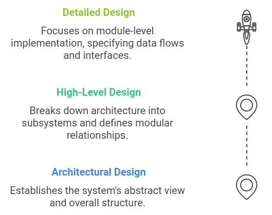

### 2. Design of Output System

1. **Definition**:
   - Outputs are **information/results** generated by the system.
2. **Key Objectives**:
   - Provide insights on **status, actions, or projections**.
   - Highlight **alerts, warnings**, or **opportunities**.
   - **Trigger actions** or confirm user operations.
3. **Steps in Output Design**:
   - Identify **what information** to present.
   - Choose the **output medium** (e.g., screen, print, voice).
   - Arrange data into a clear **layout** (headings, columns).
   - Define the **distribution method** for recipients.
4. **Output Types**:
   - **Reports**: Detailed summaries or analytical insights.
   - **Notifications**: Alerts and messages.
   - **Documents**: Help manuals, receipts.
5. **Presentation Formats**:
   - Tabular, graphical, icons, or **color-coded displays**.

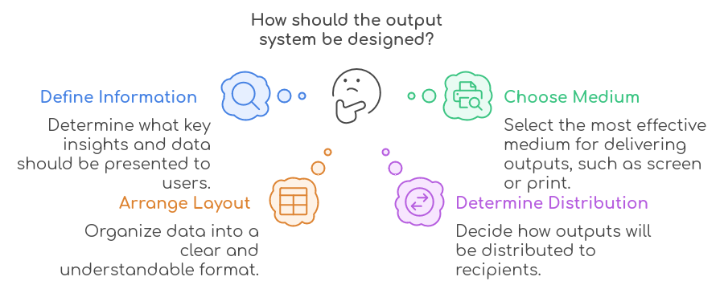

### 3. Form Design

1. **Definition**:
   - A form is a **data entry interface** for capturing system inputs.
2. **Key Considerations**:
   - **Layout**: Logical arrangement of fields and sections.
   - **Captions**: Clear prompts for data input.
   - **Coding Methods**: Unique identifiers, efficient storage.
   - **Data Capture Tools**: Keyboards, scanners, or punch cards.
3. **Sections of a Form**:
   - **Heading**: Title of the form.
   - **Identification**: Details for access or tracking.
   - **Instructions**: Guidelines for completion.
   - **Body**: Core fields for data entry.
   - **Verification**: Signature or confirmation section.
   - **Comments**: Space for notes or additional input.
4. **Good Design Principles**:
   - **Ease of Use**: Intuitive and simple.
   - **Accuracy**: Minimize errors with clear instructions.
   - **Attractiveness**: Clean and uncluttered layout with appropriate visuals.
   - Use **fonts, colors**, and prompts to guide users effectively.

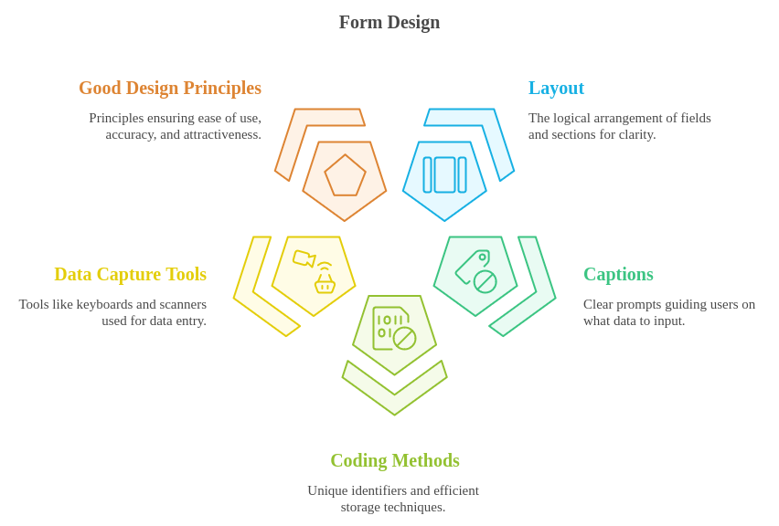